# Business Understanding

What is the business need?

- Definition of the business objectives
- business process mapping
- identification of stakeholders and main indicators.

Time Series Forecasting

Data Science

Hierarchical Forecasting (HTS)

Error-Trend-Season (ETS)

Supply Chain Management

Authors

Affiliation

[Floris Padt, MSc.](https://www.linkedin.com/in/florispadt)

[EAISI - Technical University Eindhoven](https://www.tue.nl/en/research/institutes/eindhoven-artificial-intelligence-systems-institute/ai-education/professional-education/programs-voor-professionals/mastering-data-ai-mdai)

[Ieke Le Blanc, Dr.](https://www.tue.nl/en/education/professional-education/current-programs/eaisi-academy/lecturers/dr-ieke-le-blanc)

[EAISI - Technical University Eindhoven](https://www.tue.nl/en/research/institutes/eindhoven-artificial-intelligence-systems-institute/ai-education/professional-education/programs-voor-professionals/mastering-data-ai-mdai)

Published

May 25, 2025

[figure not shown]

Figure 6.1: Why forecasting?  
The forecast drives the business!

See Figure Figure 9.1 for the thumbnail overview.

## 6.1 Table

table4, keep

Shipments by Origin → Destination

Metrics grouped by origin using GT row groups

| Metric | TO BE | TO DE | TO FR | TO GB | TO IT | TO NL |
| --- | --- | --- | --- | --- | --- | --- |
| 3P |  |  |  |  |  |  |
| Count (n) | 2 | 8 | 13 | 7 | 5 | 11 |
| Average Items | 14.0 | 18.9 | 97.1 | 17.9 | 10.6 | 18.7 |
| Max Items | 19 | 77 | 402 | 44 | 20 | 52 |
| DE |  |  |  |  |  |  |
| Count (n) | NA | 4 | 3 | 2 | 2 | 3 |
| Average Items | NA | 58.5 | 21.0 | 4.5 | 3.5 | 17.3 |
| Max Items | NA | 135 | 32 | 7 | 5 | 32 |
| ES |  |  |  |  |  |  |
| Count (n) | NA | NA | 3 | NA | 2 | NA |
| Average Items | NA | NA | 2.3 | NA | 5.5 | NA |
| Max Items | NA | NA | 5 | NA | 6 | NA |
| FR |  |  |  |  |  |  |
| Count (n) | NA | NA | 1 | 1 | NA | 1 |
| Average Items | NA | NA | 152.0 | 4.0 | NA | 10.0 |
| Max Items | NA | NA | 152 | 4 | NA | 10 |
| GB |  |  |  |  |  |  |
| Count (n) | NA | 1 | 1 | 1 | 2 | 2 |
| Average Items | NA | 61.0 | 84.0 | 163.0 | 23.5 | 85.5 |
| Max Items | NA | 61 | 84 | 163 | 45 | 168 |
| IT |  |  |  |  |  |  |
| Count (n) | 1 | 1 | 1 | 1 | 1 | 1 |
| Average Items | 1.0 | 22.0 | 155.0 | 3.0 | 194.0 | 25.0 |
| Max Items | 1 | 22 | 155 | 3 | 194 | 25 |

table5, delete?

Shipments by Origin → Destination

Manual row grouping with pure data.table syntax

| Metric | TO BE | TO DE | TO FR | TO GB | TO IT | TO NL |
| --- | --- | --- | --- | --- | --- | --- |
| IT |  |  |  |  |  |  |
| Average Items | 1.0 | 22.0 | 155.0 | 3.0 | 194.0 | 25.0 |
| Count (n) | 1 | 1 | 1 | 1 | 1 | 1 |
| Max Items | 1 | 22 | 155 | 3 | 194 | 25 |
| GB |  |  |  |  |  |  |
| Average Items | NA | 61.0 | 84.0 | 163.0 | 23.5 | 85.5 |
| Count (n) | NA | 1 | 1 | 1 | 2 | 2 |
| Max Items | NA | 61 | 84 | 163 | 45 | 168 |
| FR |  |  |  |  |  |  |
| Average Items | NA | NA | 152.0 | 4.0 | NA | 10.0 |
| Count (n) | NA | NA | 1 | 1 | NA | 1 |
| Max Items | NA | NA | 152 | 4 | NA | 10 |
| ES |  |  |  |  |  |  |
| Average Items | NA | NA | 2.3 | NA | 5.5 | NA |
| Count (n) | NA | NA | 3 | NA | 2 | NA |
| Max Items | NA | NA | 5 | NA | 6 | NA |
| DE |  |  |  |  |  |  |
| Average Items | NA | 58.5 | 21.0 | 4.5 | 3.5 | 17.3 |
| Count (n) | NA | 4 | 3 | 2 | 2 | 3 |
| Max Items | NA | 135 | 32 | 7 | 5 | 32 |
| 3P |  |  |  |  |  |  |
| Average Items | 14.0 | 18.9 | 97.1 | 17.9 | 10.6 | 18.7 |
| Count (n) | 2 | 8 | 13 | 7 | 5 | 11 |
| Max Items | 19 | 77 | 402 | 44 | 20 | 52 |

table6, delete?

Shipments by Origin → Destination

Origin grouping displayed in left column

| FROM | Metric | TO BE | TO DE | TO FR | TO GB | TO IT | TO NL |
| --- | --- | --- | --- | --- | --- | --- | --- |
| 3P | Average Items | 14.0 | 18.9 | 97.1 | 17.9 | 10.6 | 18.7 |
|  | Count (n) | 2 | 8 | 13 | 7 | 5 | 11 |
|  | Max Items | 19 | 77 | 402 | 44 | 20 | 52 |
| DE | Average Items | NA | 58.5 | 21.0 | 4.5 | 3.5 | 17.3 |
|  | Count (n) | NA | 4 | 3 | 2 | 2 | 3 |
|  | Max Items | NA | 135 | 32 | 7 | 5 | 32 |
| ES | Average Items | NA | NA | 2.3 | NA | 5.5 | NA |
|  | Count (n) | NA | NA | 3 | NA | 2 | NA |
|  | Max Items | NA | NA | 5 | NA | 6 | NA |
| FR | Average Items | NA | NA | 152.0 | 4.0 | NA | 10.0 |
|  | Count (n) | NA | NA | 1 | 1 | NA | 1 |
|  | Max Items | NA | NA | 152 | 4 | NA | 10 |
| GB | Average Items | NA | 61.0 | 84.0 | 163.0 | 23.5 | 85.5 |
|  | Count (n) | NA | 1 | 1 | 1 | 2 | 2 |
|  | Max Items | NA | 61 | 84 | 163 | 45 | 168 |
| IT | Average Items | 1.0 | 22.0 | 155.0 | 3.0 | 194.0 | 25.0 |
|  | Count (n) | 1 | 1 | 1 | 1 | 1 | 1 |
|  | Max Items | 1 | 22 | 155 | 3 | 194 | 25 |

### 6.1.1 hybrid grouping

Shipments by Origin → Destination

Enhanced left-column grouping with visual indicators

| FROM | Metric | TO BE | TO DE | TO FR | TO GB | TO IT | TO NL |
| --- | --- | --- | --- | --- | --- | --- | --- |
| 3P | Average Items | 14.0 | 18.9 | 97.1 | 17.9 | 10.6 | 18.7 |
|  | Count (n) | 2 | 8 | 13 | 7 | 5 | 11 |
|  | Max Items | 19 | 77 | 402 | 44 | 20 | 52 |
| DE | Average Items | NA | 58.5 | 21.0 | 4.5 | 3.5 | 17.3 |
|  | Count (n) | NA | 4 | 3 | 2 | 2 | 3 |
|  | Max Items | NA | 135 | 32 | 7 | 5 | 32 |
| ES | Average Items | NA | NA | 2.3 | NA | 5.5 | NA |
|  | Count (n) | NA | NA | 3 | NA | 2 | NA |
|  | Max Items | NA | NA | 5 | NA | 6 | NA |
| FR | Average Items | NA | NA | 152.0 | 4.0 | NA | 10.0 |
|  | Count (n) | NA | NA | 1 | 1 | NA | 1 |
|  | Max Items | NA | NA | 152 | 4 | NA | 10 |
| GB | Average Items | NA | 61.0 | 84.0 | 163.0 | 23.5 | 85.5 |
|  | Count (n) | NA | 1 | 1 | 1 | 2 | 2 |
|  | Max Items | NA | 61 | 84 | 163 | 45 | 168 |
| IT | Average Items | 1.0 | 22.0 | 155.0 | 3.0 | 194.0 | 25.0 |
|  | Count (n) | 1 | 1 | 1 | 1 | 1 | 1 |
|  | Max Items | 1 | 22 | 155 | 3 | 194 | 25 |

# 7 GGPlots

ggplot and spark

Lead Time Analysis by Category

Distribution plots with mean (red dashed) and median (orange dotted) lines

Category

Count

Mean

Median

Std Dev

Min

Max

95th %ile

Distribution

Non category specific

4

3.0

3.5

1.4

1.0

4.0

4.0

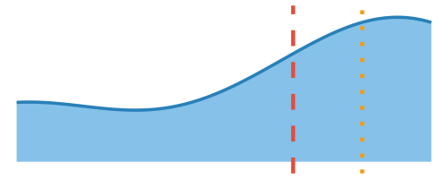

Functional Foods

5

7.4

5.0

8.4

1.0

22.0

18.8

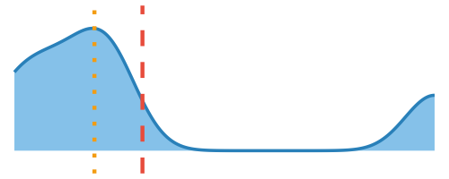

Others

5

10.4

13.0

7.1

1.0

17.0

16.8

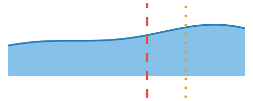

Breakfast Cereals

10

15.1

4.5

17.2

1.0

45.0

42.3

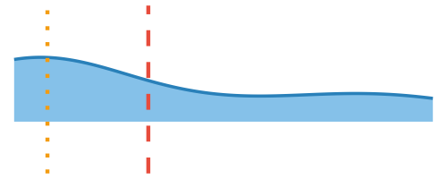

Bread and Biscuit Alternatives

5

19.4

19.0

13.2

2.0

35.0

33.8

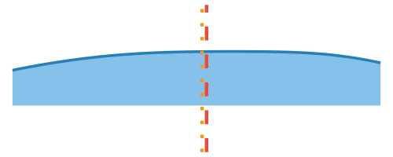

Sweet Spreads, Purees, Sweeteners

7

24.9

16.0

40.3

2.0

115.0

85.6

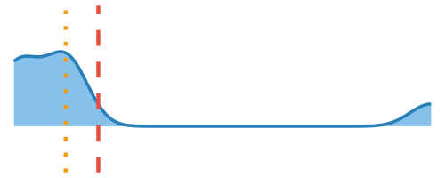

Bread and Bakery

1

30.0

30.0

NA

30.0

30.0

30.0

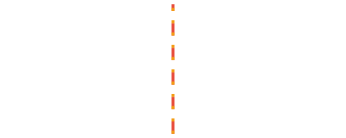

Juices and Cold Drinks

3

36.3

34.0

27.6

10.0

65.0

61.9

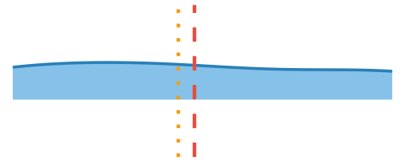

Sweets in Between

8

52.8

27.0

87.8

2.0

267.0

188.9

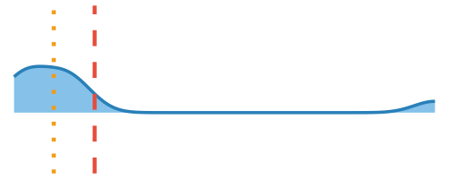

Dairy Alternatives

10

53.8

21.0

70.2

1.0

194.0

176.4

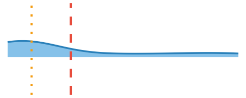

Hot Drinks

13

64.8

51.0

59.4

4.0

168.0

165.0

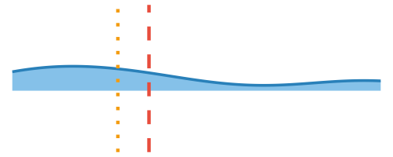

Meals and Meal components

9

79.1

22.0

128.3

1.0

402.0

295.2

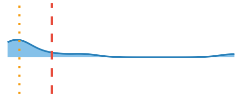

Animal based products

1

123.0

123.0

NA

123.0

123.0

123.0

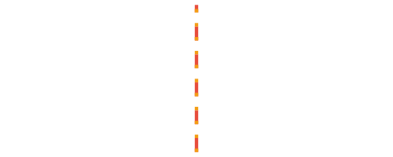

# 8 Sparklines

# 9 flextable

works in HTML & PDF

Category

Count

Mean

Distribution

Bread and Biscuit Alternatives

5

19.4

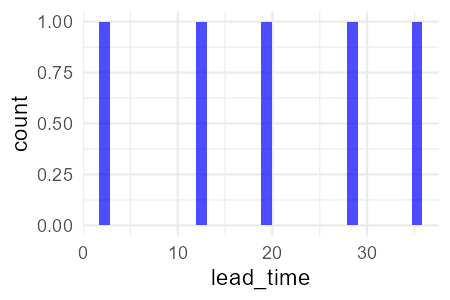

Dairy Alternatives

10

53.8

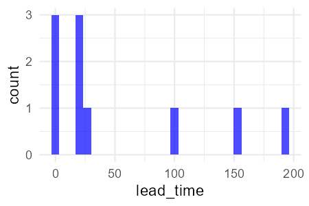

Sweets in Between

8

52.8

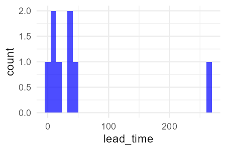

Others

5

10.4

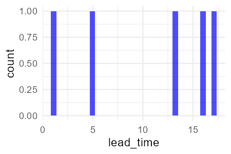

Meals and Meal components

9

79.1

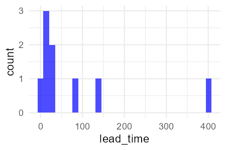

Sweet Spreads, Purees, Sweeteners

7

24.9

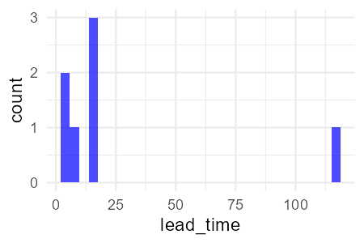

Breakfast Cereals

10

15.1

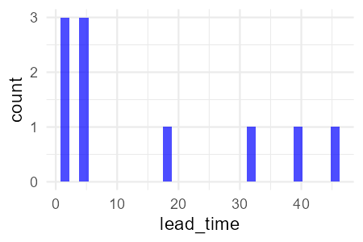

Functional Foods

5

7.4

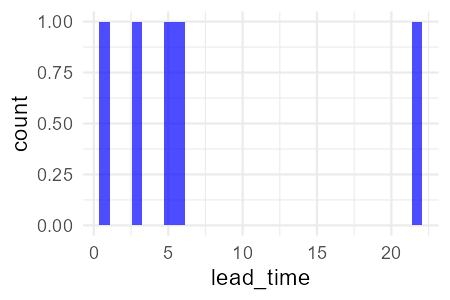

Hot Drinks

13

64.8

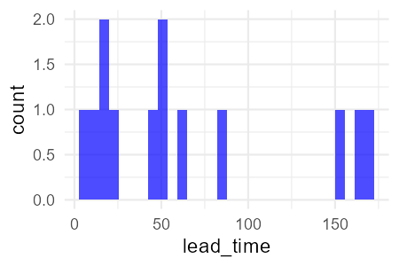

Bread and Bakery

1

30.0

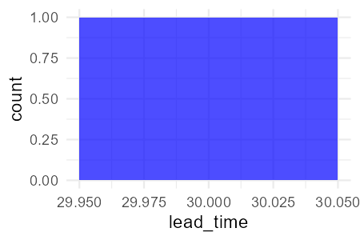

Juices and Cold Drinks

3

36.3

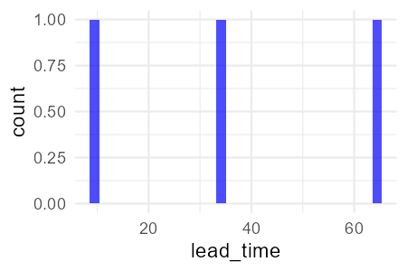

Animal based products

1

123.0

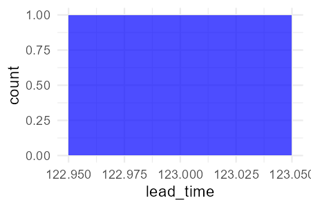

Non category specific

4

3.0

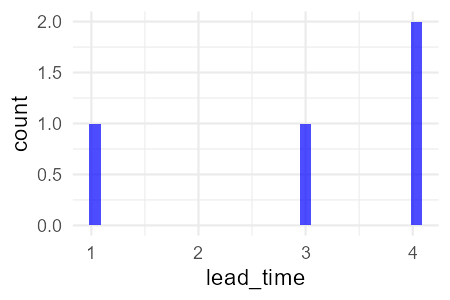

[figure not shown]

supply chain network (sample)

1. **Buying and Production**: Requires forecasts at the **material level** and **warehouse**, aggregated weekly, with a forecast horizon of **12 weeks**.
2. **Setting Safety Stock Profiles**: Requires forecasts at the **material level** and **warehouse**, aggregated weekly, with a forecast horizon of **26-52 weeks**, to determine safety stock profiles based on realized forecast accuracy.
3. **Negotiation with Customers**: Requires forecasts at a **monthly level**, aggregated by **material categories** and **customer groups**, with a horizon of **6 months**.
4. **Production Cost Calculation**: Requires forecasts at a **quarterly level**, aggregated by material, with a horizon of **6 quarters**, grouped into annual time buckets.

The primary forecasting challenge is determining the optimal aggregation level and methods to use for generating forecasts that can meet the desired forecast accuracy of these different use cases while ensuring **consistency** and **accuracy**.

This inconsistency stems from a lack of objective criteria for selecting between forecasting methods—**bottom-up**, **top-down**, or **middle-out**—resulting in decisions that rely on the subjective judgment of demand planners, leading to variable performance and inefficiencies.

### 9.0.1 Business Objectives

The primary objective is to enhance operational efficiency by improving forecast accuracy across all key use cases. This will be achieved through the application of robust forecasting methods that can handle seasonality, promotions, and efficiently allocate scarce resources. Ultimately, these improvements will contribute to improved stock levels and a higher level of customer satisfaction, both key strategic goals for the company.

### 9.0.2 Business Success Criteria

Success will be measured by the following criteria:

1. **Improved Forecast Accuracy**:
   - **Tailored Forecasts for Each Use Case**: Enhanced accuracy across areas such as buying, production, safety stock settings, and customer negotiations, using methods that account for seasonality, promotions, and varying aggregation levels.
   - **Reduced Forecast Errors and Bias**: Measurable reductions in key error metrics like RMSE , MAPE , and BIAS will lead to better alignment between forecasted and actual sales. Increased accuracy will also foster trust among supply planners, reducing the need for excessive safety margins.
   - **Consistency Across Aggregation Levels**: Forecasts will remain consistent across different levels of aggregation, ensuring that detailed and aggregated forecasts are aligned.
2. **Informed Decision-Making for Forecasting System Functionality**:
   - **Selecting the Right Forecasting Methods**: This research will guide the selection of optimal forecasting methods (statistical, machine learning, or hybrid) to improve performance across various use cases.
   - **Efficient Resource Allocation**: A product classification scheme (e.g., ABC-XYZ) will be developed to help demand planners focus on high-impact products, while low-impact products will be managed more efficiently through automated forecasts.
3. **Operational Benefits**:
   - **Improved Inventory Management**: More accurate forecasts will drive better purchasing and production decisions, leading to:
     - **Reduced Out-of-Stock (OOS) Incidents**: Ensuring product availability to meet customer demand and reduce penalties from stock-outs.
     - **Reduced Out-of-Date (OOD) Incidents**: Minimizing waste and ensuring the freshness of perishable goods, leading to lower storage costs and better inventory turnover.
   - **Optimized Safety Stock Levels**: Accurate forecasts will allow for better safety stock settings, reducing both overstocking and stock-outs.
   - **Cost Optimization**: Improved demand alignment will lower excess inventory and warehousing costs, minimize spoilage, and reduce costs associated with last-minute adjustments and overproduction.
4. **Enhanced Supply Chain Efficiency and Decision-Making**:
   - **Strategic Decision Support**: Consistent and accurate forecasts will improve decision-making across production planning, sales target setting, capacity management, and workforce optimization. These improvements will also support better customer negotiations and more precise COGS (Cost of Goods Sold) calculations, resulting in a more efficient supply chain.
   - **Increased Customer Satisfaction**: Improved product availability, fewer stock-outs, and fresher goods will not only reduce operational costs but will also enhance customer satisfaction and loyalty—a core strategic objective of the company.

By achieving these objectives, the company will see significant improvements in operational efficiency, cost-effectiveness, and most importantly, a higher level of customer satisfaction, which will ultimately drive long-term business success.

see upper part of the flow-down graph, (Section 13.1).

### 9.0.3 Inventory of Resources Requirements

#### 9.0.3.1 Data sources:

The available data includes **historical sales**, **promotional data**, **stock quantities**, and **previous forecasts**. Stock-out periods will be adjusted for by inflating sales to reflect demand that would have occurred had stock been available.

| Data Type | Details | Time Span |
| --- | --- | --- |
| Sales | Customer Orders, Inter-company, Returns, Free-of-Charge and Missed | > 2020 |
| Promotions | Promotions per material and customer | > 2020 |
| Stock | Daily stock level per material and distribution center | > 2020 |
| Forecasts | generated forecast before- and after Demand Review | > Aug. 2023 |
| Master data | Material, Customer and Organization, including hierarchy’s | *N.A.* |

#### 9.0.3.2 Scoping

The scope of the project consist of two Marketing & Sales Organizations (MSO), with a focus on 6 brands, representing 5 out of the 6 categories, see Table 9.1. These materials are made-to-stock (MTS), requirements are planned on a weekly level, which represents 97% of the business.

This leaves us with about 1.000 materials out of 9.000 to focus on, making the assumption that these are representative for the rest of the products.

Table 9.1: Brands and Categories

| Brand | Category |
| --- | --- |
| Bjorg | Dairy |
| Clipper | Tea / Coffee |
| Naturela | Tea / Coffee |
| Tanoshi | Meals |
| Alter Eco | Sweets |
| Zonnatura | Breakfast Cereals |

### 9.0.4 Data Mining Goals

Predictive Model based on Correlations: Forecast Future Sales + Promotion effects

see lower part of the flow-down graph, (Section 13.1).

#### Data and Forecasting Methods

We will employ a combination of **statistical methods** and **machine learning techniques** to improve the forecasting process:

- **Current Methods**: The company’s current forecasting system uses **moving averages**, **exponential smoothing** and **Box-Jenkins**, which face challenges with **Seasonality**, **Stationarity** and **promotional effects**. Forecasts are often inadequate in handling the impacts of promotions.
- **Proposed Methods**:
  - **ETS (Error, Trend, Seasonal)**: To replace exponential smoothing with a model that provides **prediction intervals** and better captures trends and seasonality.
  - **HTS (Hierarchical Time Series)**: To handle multiple aggregation levels, ensuring **forecast consistency** when forecasts are disaggregated or aggregated across levels.
  - **XGBoost**: A machine learning technique capable of handling **promotional impacts** and even identifying **cannibalization effects** of promotions between products.
  - **conformal prediction**: A method that provides **prediction intervals** and **calibrated forecasts**, ensuring that the forecasted values are within a certain confidence level.
  - **CatBoost and SHAP**: These will be used for feature analysis, determining which features (e.g., promotions, stock-outs) have the highest impact on forecast accuracy. This approach helps in choosing relevant input features to improve forecasts.

#### Consistency and Validation

One key requirement is ensuring that forecasts remain consistent across different levels of aggregation. This is where **HTS** will play a crucial role, reconciling forecasts generated at different aggregation levels to ensure that top-level forecasts align with aggregated lower-level forecasts. This will address the known issue of discrepancies between aggregated forecasts and directly forecasted aggregated levels.

#### 9.0.4.1 **Human Resources Allocation**

To optimize resource allocation, we plan to implement a **classification system** for the company’s **9K SKUs**, utilizing an:

**ABC-XYZ classification** scheme:

- **ABC Classification**: Based on **sales volume**—focusing more resources on high-value items (A-class) and minimizing attention to low-volume items (C-class).
- **XYZ Classification**: Based on **sales variability**, indicating which products have stable demand versus those with erratic patterns.
- **Combined Classification**: These classifications will guide planners in determining where their efforts can have the most impact, focusing primarily on high-priority items while relying more on automated processes for low-priority ones.

### 9.0.5 Data Mining Success Criteria

The fiinal result will show an estimated relationship between forecast accuracy and the cost of resources required for the agreed scope. The cost of resources result from hardware, software and human resources needed for cleansing data, transforming data, model tuning and other manual activities needed.

To assess forecast accuracy, we will use a range of evaluation metrics tailored to each use case.

These metrics will help evaluate how well each approach performs against the unique requirements of each use case, ultimately guiding method selection and refinement.

- **RMSE (Root Mean Squared Error, def 9.1 )**: The primary metric for measuring forecast accuracy, particularly useful for penalizing large errors.
- **MAPE (Mean Absolute Percentage Error)**: To align with existing company metrics.
- **MAE (Mean Absolute Error)** and **MASE (Mean Absolute Scaled Error)**: Additional metrics to provide a broader evaluation, addressing different aspects of forecast performance and comparing models to naïve baselines.

### 9.0.6 Project Plan

see Section 12.7

#### 9.0.6.1 Initial Assessment of Tools and Techniques

see Literature review (Section 12.1)

**def 9.1** **RMSE:**

Root Mean Squared Error

RMSE = $\sqrt{mean(e^2_t)}$

A [Scale-dependent error](https://otexts.com/fpp3/accuracy.html#scale-dependent-errors), to compare forecast performances between data sets with the same unit.

Barrett, T., Dowle, M., Srinivasan, A., Gorecki, J., Chirico, M., Hocking, T., Schwendinger, B., Stetsenko, P., Short, T., Lianoglou, S., Antonyan, E., Bonsch, M., Parsonage, H., Ritchie, S., Ren, K., Tan, X., Saporta, R., Seiskari, O., Dong, X., … Krylov, I. (2024). *Data.table: Extension of ’data.frame’*. https://cran.r-project.org/web/packages/data.table/index.html

BLOKDYK, G. (2019). *SCOR MODEL A COMPLETE GUIDE - 2020 EDITION*. 5STARCOOKS.

Core Team}, {R. (2024). *R: A Language and Environment for Statistical Computing*. R Foundation for Statistical Computing. https://www.R-project.org/

Costa, R. (2022). *The CRISP-ML Methodology: A Step-by-Step Approach to Real-World Machine Learning Projects*. Independently published.

DeBruine, L. (2023). *Glossary: Glossaries for Markdown and Quarto Documents*. https://cran.r-project.org/web/packages/glossary/

Guja, A., & Siwiak, M. (2025). *Generative AI for Data Analytics.* Manning Publications Co. LLC 2025.

Hartshorn, S. (2017). *Machine Learning With Boosting: A Beginner’s Guide*.

Hyndman [aut, R., cre, cph, Athanasopoulos, G., Bergmeir, C., Caceres, G., Chhay, L., Kuroptev, K., O’Hara-Wild, M., Petropoulos, F., Razbash, S., Wang, E., Yasmeen, F., Garza, F., Girolimetto, D., Ihaka, R., R Core Team, Reid, D., Shaub, D., … Zhou, Z. (2024). *Forecast: Forecasting functions for time series and linear models*. https://cran.r-project.org/web/packages/forecast/index.html

Hyndman [aut, R., cre, cph, Athanasopoulos, G., O’Hara-Wild, M., Palihawadana, N., Wickramasuriya, S., & RStudio. (2024). *fpp3: Data for "Forecasting: Principles and Practice" (3rd Edition)*. https://cran.r-project.org/web/packages/fpp3/index.html

Hyndman, R. J., & Athanasopoulos, G. (2021). *Forecasting: Principles and Practice (3rd ed)*. https://otexts.com/fpp3/

Kunapuli, G. (2023). *Ensemble methods for machine learning*. Manning.

Manokhin, V. (2023). *Practical guide to applied conformal prediction in Python: Learn and apply the best uncertainty frameworks to your industry applications*. <packt>.

Matthes, E. (2019b). *Python crash course: A hands-on, project-based introduction to programming* (2nd edition). No Starch Press.

Matthes, E. (2019a). *Python crash course: A hands-on, project-based introduction to programming* (2nd edition). No Starch Press.

Molnar, C. (2023). *Introduction to conformal prediction with Python: A short guide for quantifying uncertainty of machine learning models* (First edition). Chistoph Molnar c/o MUCBOOK, Heidi Seibold. https://christophmolnar.com/books/conformal-prediction/

*Nixtla/hierarchicalforecast: Probabilistic hierarchical forecasting 👑 with statistical and econometric methods.* (n.d.). https://github.com/Nixtla/hierarchicalforecast

*Nixtla/mlforecast*. (2024). Nixtla. https://github.com/Nixtla/mlforecast

*Nixtla/statsforecast*. (2024). Nixtla. https://github.com/Nixtla/statsforecast

*Nixtla/tsfeatures*. (2024). Nixtla. https://github.com/Nixtla/tsfeatures

O’Hara-Wild, M., Hyndman, R., Wang, E., Cook, D., features), T. T. (Correlation., & method), L. C. (Guerrero’s. (2024). *Feasts: Feature extraction and statistics for time series*. https://cran.r-project.org/web/packages/feasts/index.html

O’Hara-Wild, M., Hyndman, R., Wang, E., implementation), G. C. (NNETAR., Bergmeir, C., Hensel, T.-G., & Hyndman, T. (2024). *Fable: Forecasting models for tidy time series*. https://cran.r-project.org/web/packages/fable/index.html

O’Sullivan, C. (2023). Introduction to SHAP with Python. In *Introduction to SHAP with Python*. https://towardsdatascience.com/introduction-to-shap-with-python-d27edc23c454

O’Sullivan, C. (2024). SHAP with Python [Course]. In *SHAP with Python*. https://adataodyssey.com/course/

Porter, L., & Zingaro, D. (2024). *Learn AI-assisted Python programming: With GitHub Copilot and ChatGPT*. Manning.

Silver, E. A., Pyke, D. F., & Thomas, D. J. (2021). *Inventory and production management in supply chains* (Fourth edition, first issued in paperback). CRC Press, Taylor & Francis Group.

Vandeput, N. (2020). *Inventory optimization: Models and simulations*. De Gruyter.

Vandeput, N. (2021). *Data science for supply chain forecasting* (Second edition). De Gruyter.

Vandeput, N. (2023). *Demand forecasting best practices*. Manning Publications Co.

Wickham, H. (n.d.). *R for data science (2e)*. https://r4ds.hadley.nz/

Wickham, H., Chang, W., Henry, L., Pedersen, T. L., Takahashi, K., Wilke, C., Woo, K., Yutani, H., Dunnington, D., Brand, T. van den, Posit, & PBC. (2024). *ggplot2: Create Elegant Data Visualisations Using the Grammar of Graphics*. https://cran.r-project.org/web/packages/ggplot2/index.html